# Data Udacity

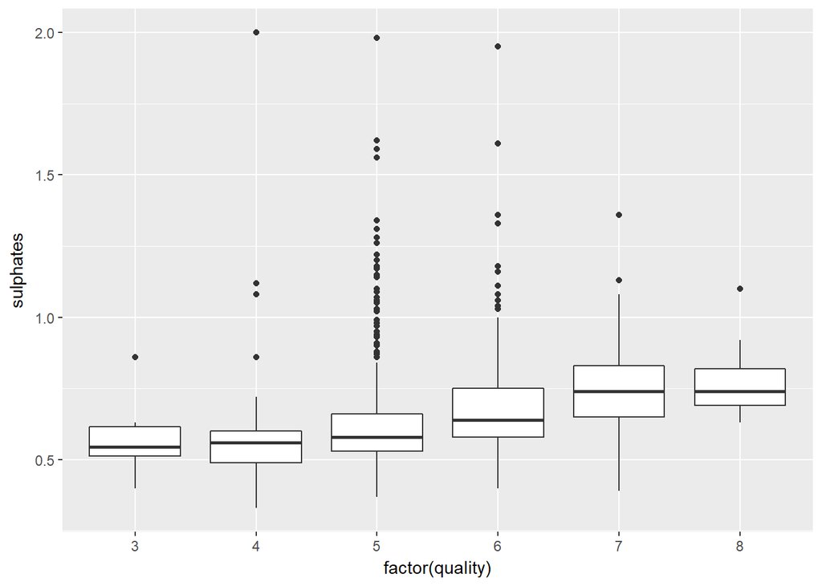

High quality wines also have an average higher value of sulphates in our data set. This can be determined with both the average and the median. This is important because there are many outliers, especially in quality levels 5 and 6, and the median tends to be less sensitive. It should also be noted that in the two highest measured quality levels (7 and 8) there are no sulphate values above 1.7, but at the lower values the Outlets go up to the value 2.

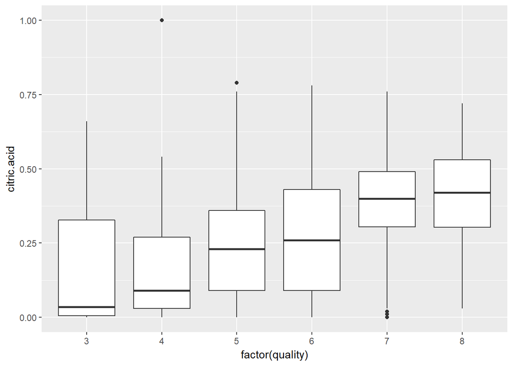

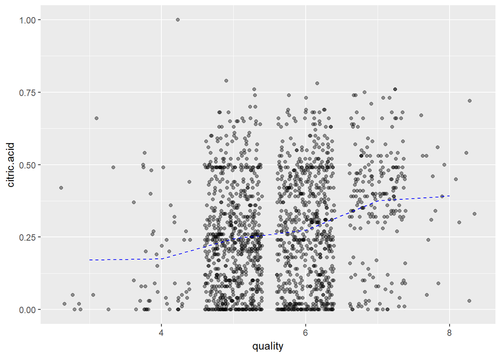

Quality and citric acid are also related. On average, the higher quality wines contain more citric acid. However, the range of values is very wide, especially in the lower quality classes. And: Even high class wines (quality 8) contain very little citric acid in individual cases.

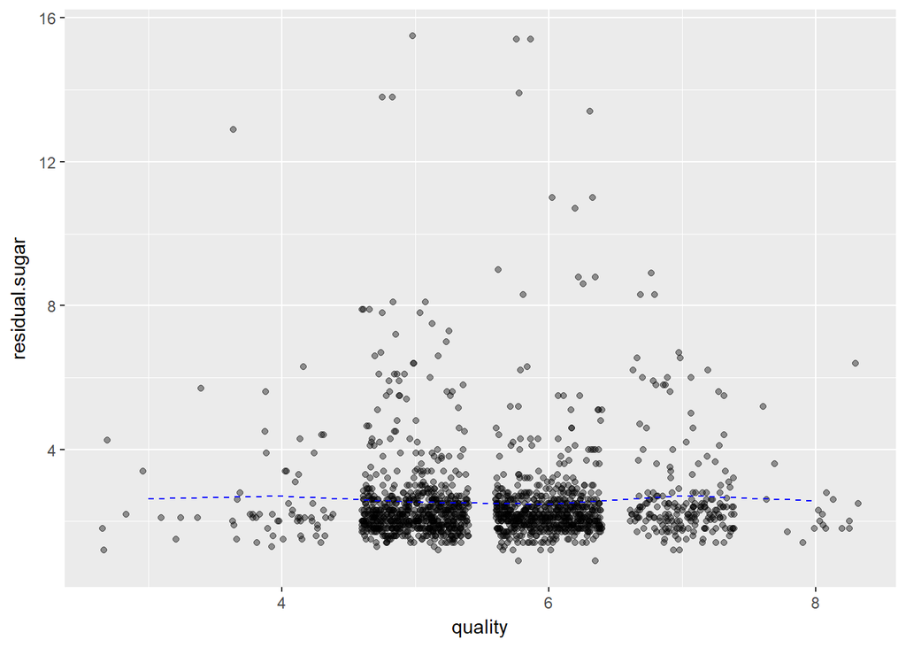

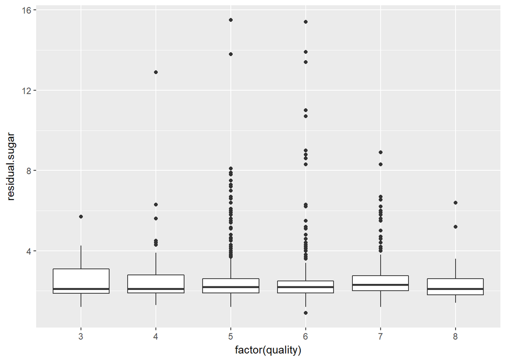

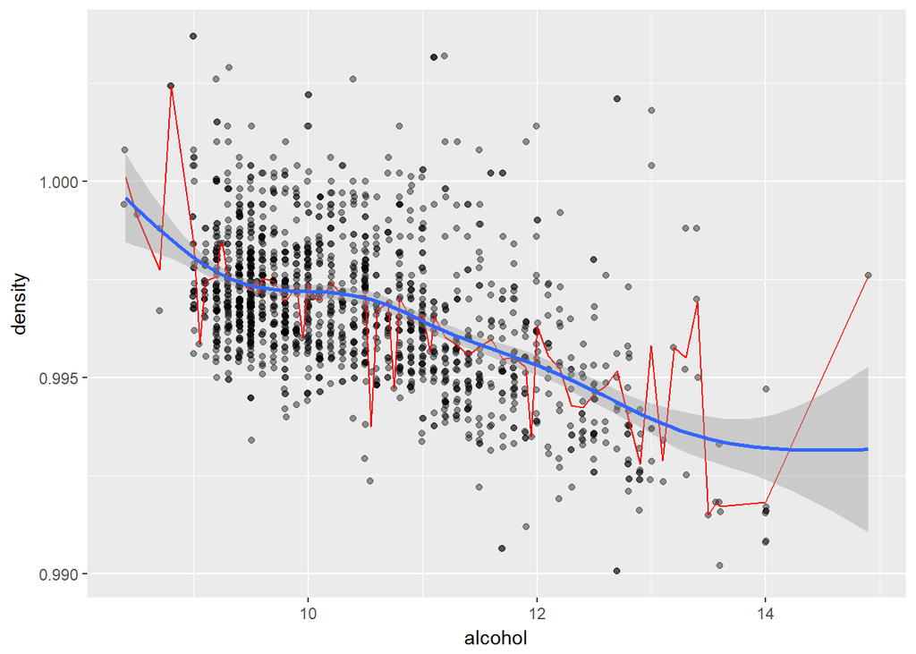

There is a correlation between density and alcohol content. As the graph shows, wines with a higher alcohol content have a lower average density.

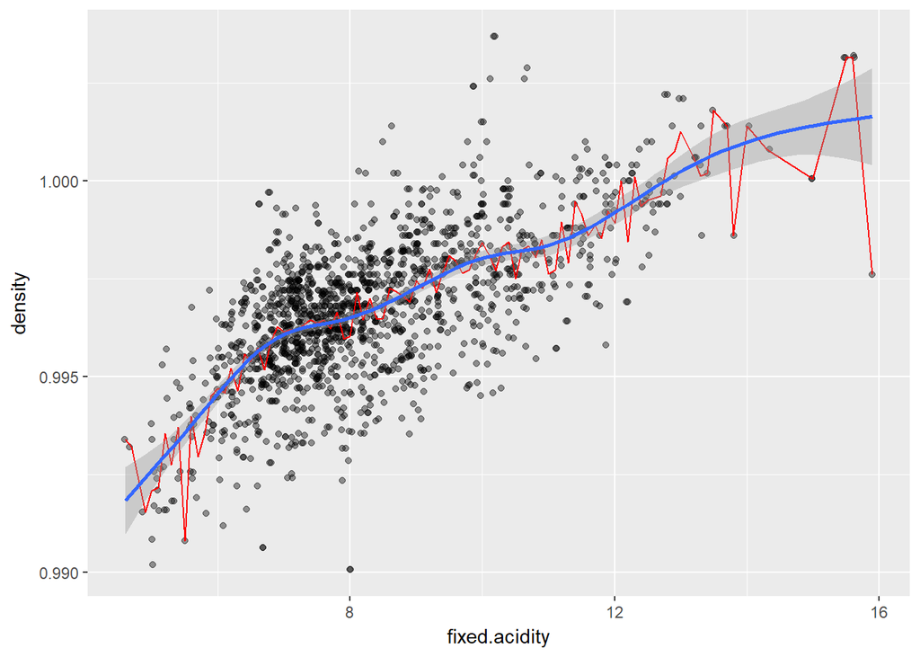

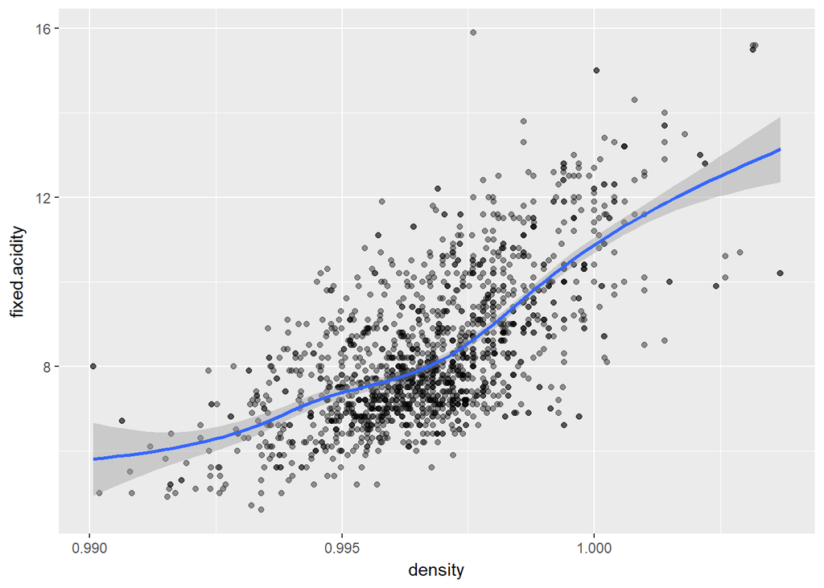

In our data set there is a relationship between the density of the wines and the fixed acidity. The higher the density of the wine, the higher the fixed acidity.

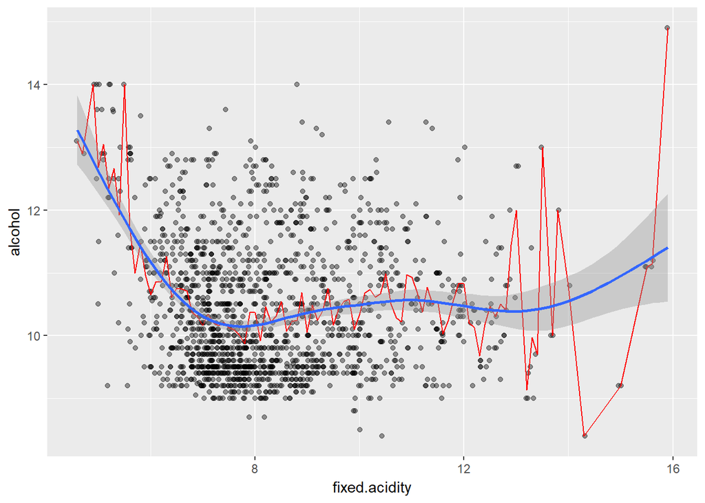

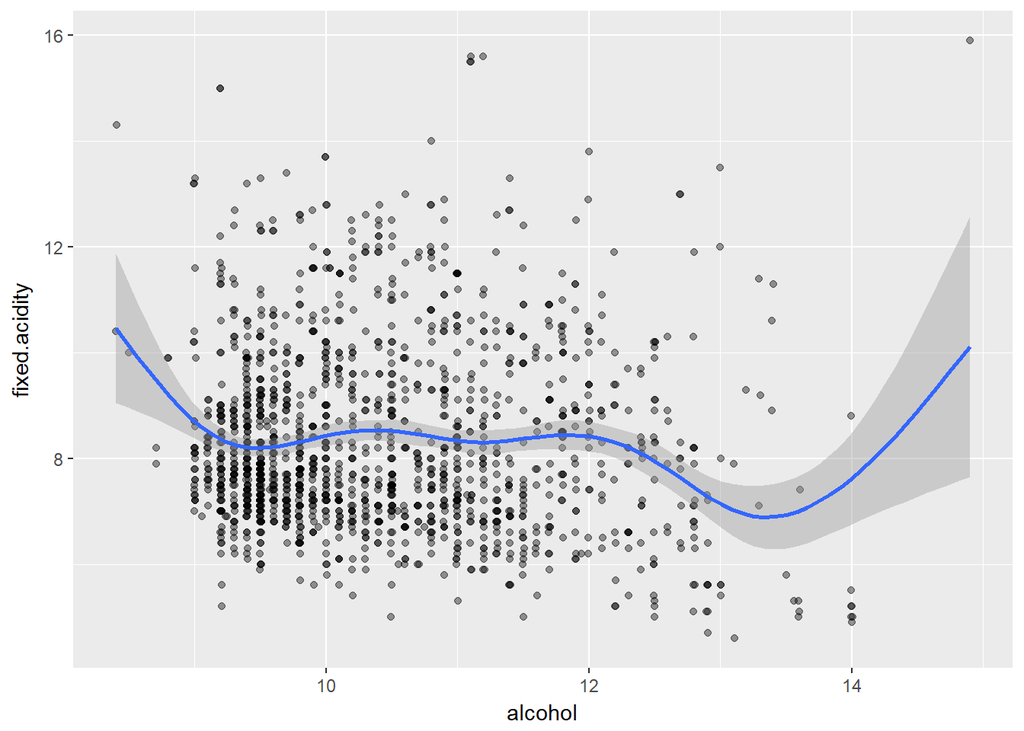

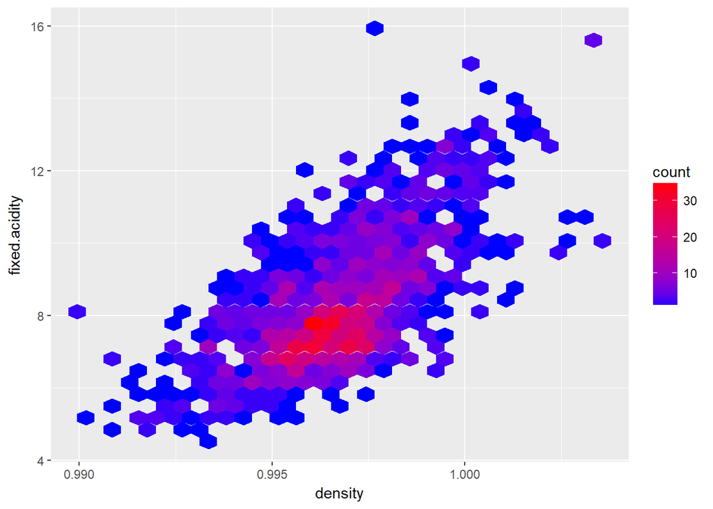

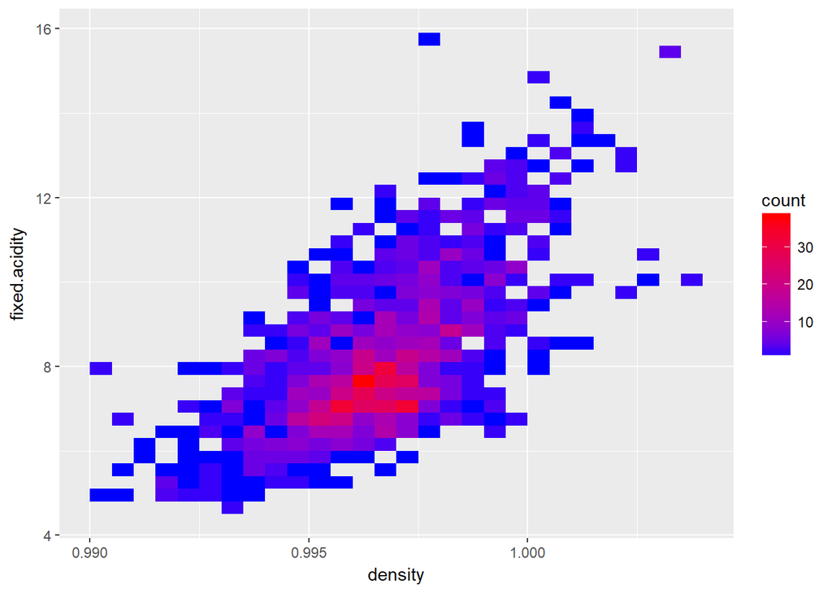

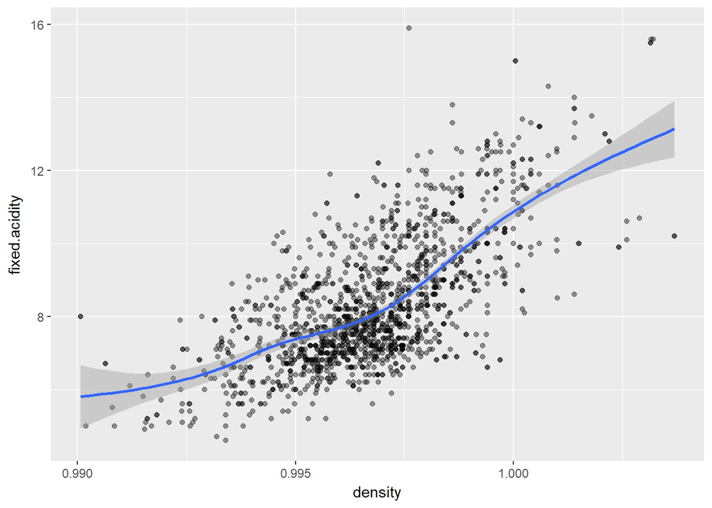

Finally, we look at the values of our variable pair with the strongest correlation - density and fixed acidity. The higher the density of the wine, the higher the fixed acidity.

# Bivariate Analysis

It should be noted that values that more or less correlate with the quality of the wine are not linked to each other. It could be assumed that - if a high alcohol value is more indicative of the quality of a wine - wines with a low proportion of volatile acidity also have a high alcohol content. However, this connection is not given in our data set.

We measured the highest correlation between the density and the proportion of fixed acidity. This allows the conclusion that during the fermentation process a wine with a high must content forms the measured acids faster than with a low must content.

# Multivariate Plots Section

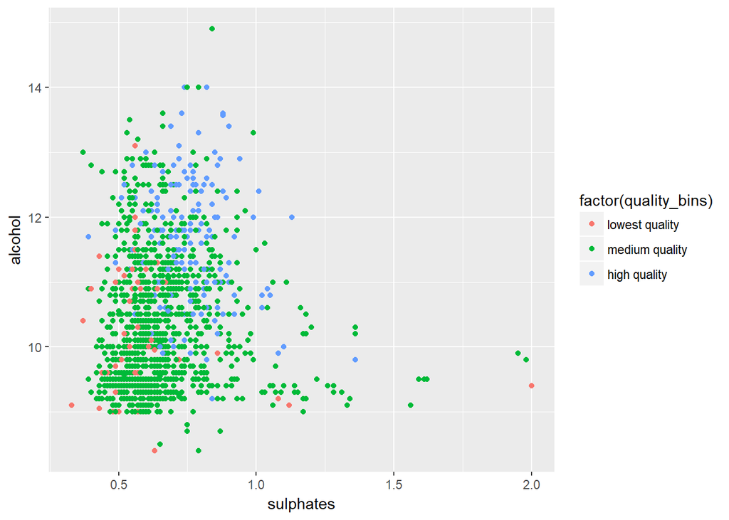

To make the analysis more meaningful, we first arrange the wines according to quality in three bins: low quality (1-4), medium quality (5-6) and high quality (7-10). When we combine the values for alcohol, sulphates and quality, we see that the wines with high quality increasingly have both a high alcohol and a high sulphur value.

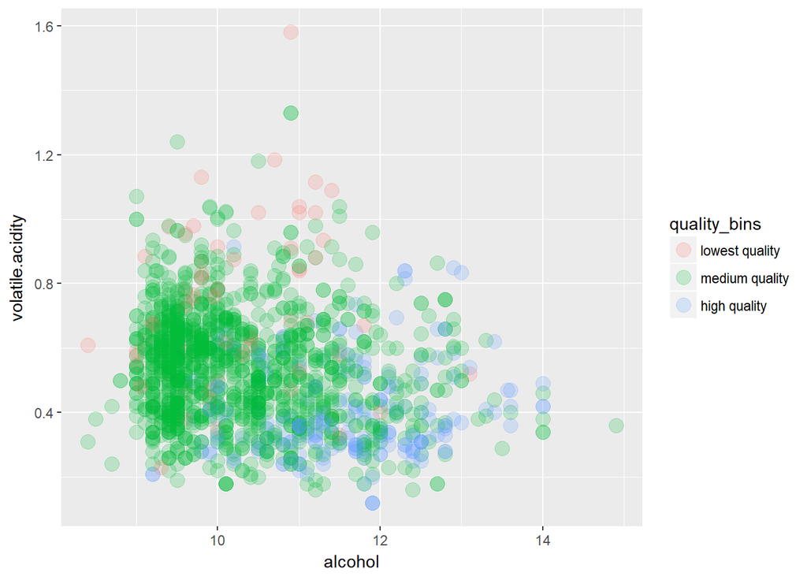

When combining volatile acidity, alcohol content and quality of wines, we find that wines of higher quality often have a higher alcohol content and a low content of volatile acidity.

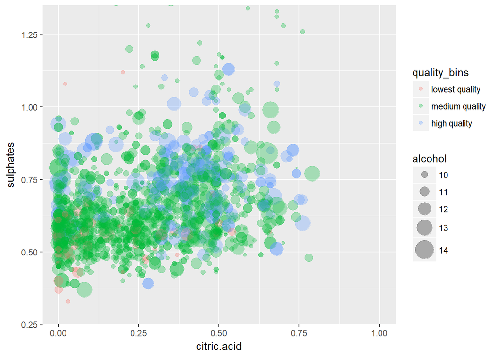

As we can see, good quality wines often contain a higher proportion of citric acid and at the same time a higher proportion of sulphur. The question of whether the alcohol content also plays a decisive role here must be answered in the negative with regard to our graph. Wines with high and low alcohol content do not show a clear pattern here. For more expressiveness, I cut the Y-axis and concentrated on the area in which most of the values lie.

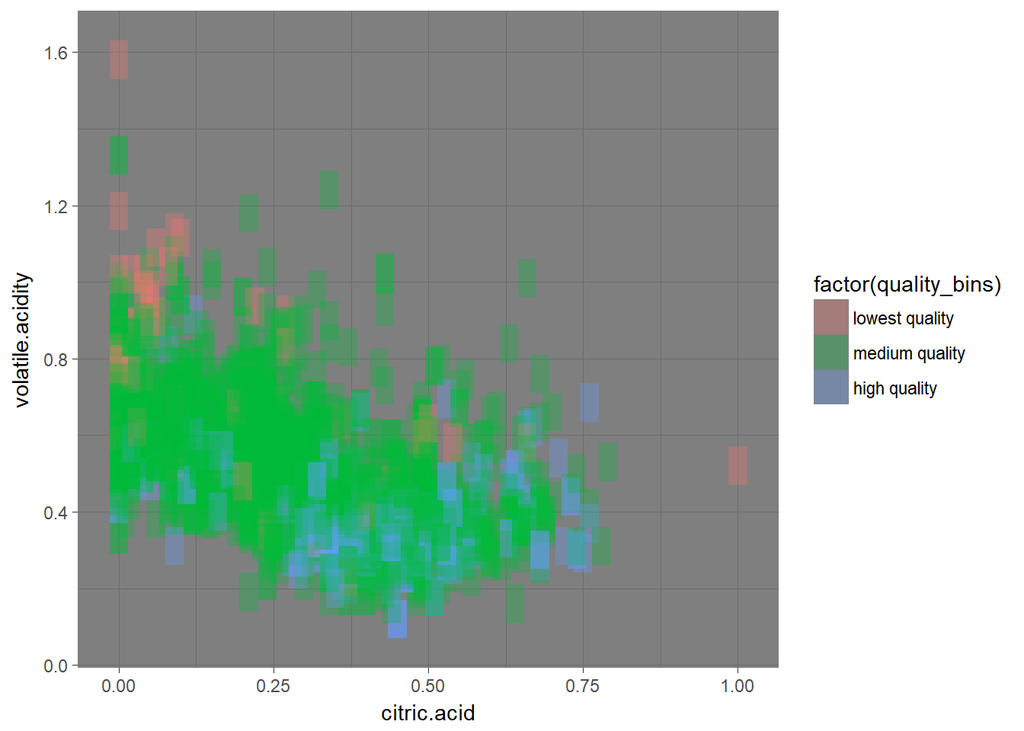

On the basis of this graph we can observe the interaction between the exploitation of volatile acidity, citric acidity and the quality level of the wine. Most of the good wines have a high level of citric acidity and a low level of volatile acidity.

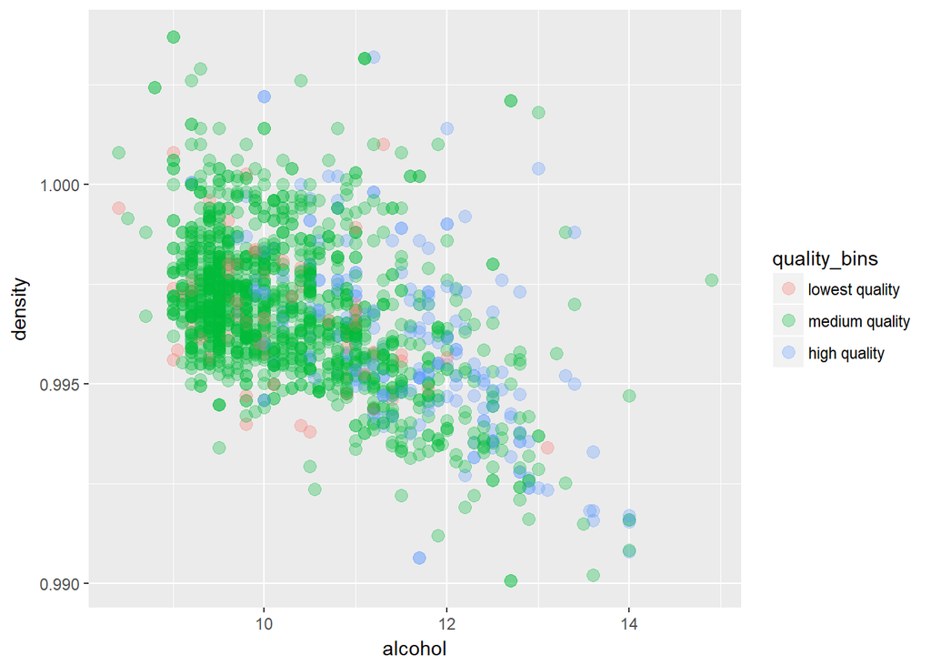

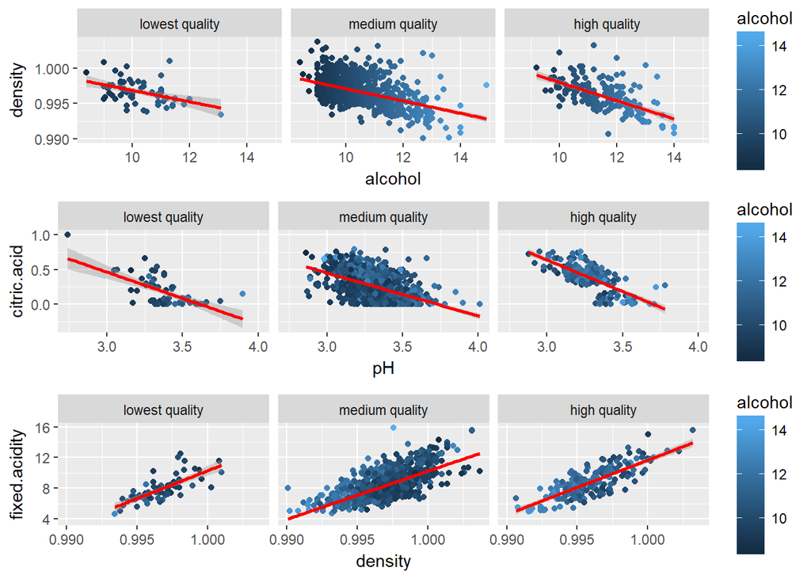

Finally, we examine whether the variables, which showed strong correlations among each other in the entire data set, behave similarly for all wine quality levels. This is the case, there are no serious differences between the individual quality levels.

# Multivariate Analysis

If we connect the variables, which also individually show a correlation with the quality, we can determine clear connections. What is surprising, however, is how many variables do not seem to have a direct effect on the quality of the wine, for example its density. This picture does not change even if we examine the wines individually according to their quality classes.

# Final Plots and Summary

### Plot One

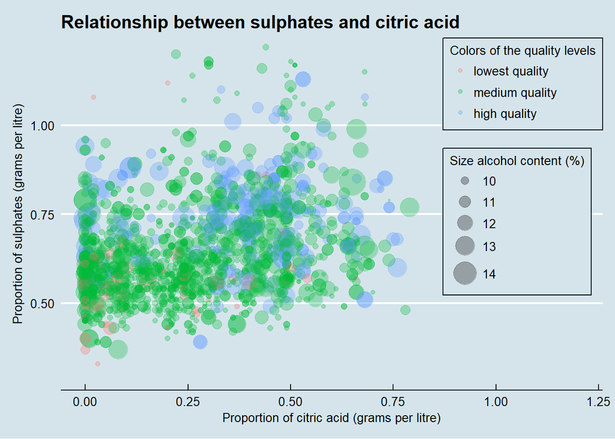

### Description One

This plot describes the ratio between sulphate and citric acid, taking into account the alcohol content and quality of the wine. This allows four different variables to be related to each other.

Clearly recognizable: The wines of the top class show rather a higher value with the sulphates, at the same time they also contain more citric acid. The wines of low quality fall behind in both categories. The alcohol content is of secondary importance.

To make the plot as attractive as possible, I cut off the Y and X axes and concentrate on the area where most of the values are located. The theme used is the economist theme (ggthemes).

### Plot Two

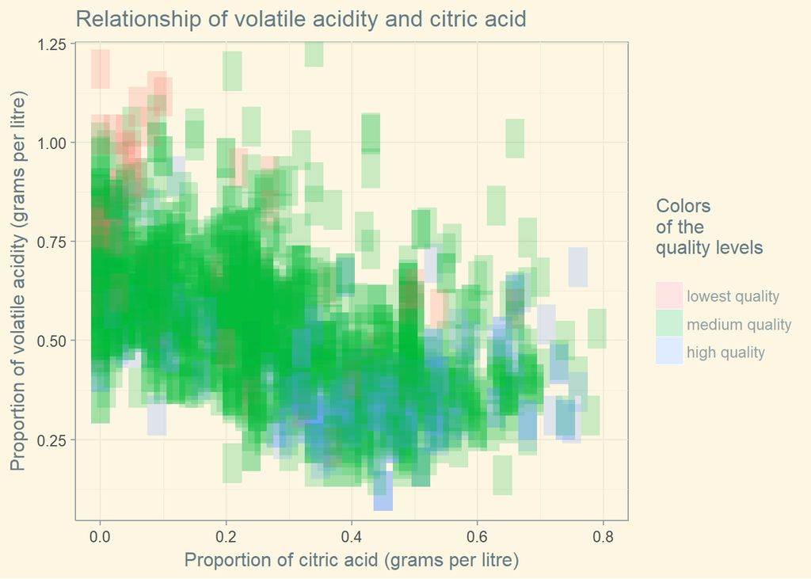

### Description Two

The second plot shows the relationship between volatile acidity and citric acidity and their effect on the quality of the wines. It should be noted that Wines of higher quality have a rather low proportion of volatile acidity and are for the most part below the average content of the wines in our data set. On the other hand, they have a higher citric acid content than rather poorer wines.

Also in this plot the X- and Y-axis were cut off, the plot concentrates on the part with especially many values. The solarize layout of the ggthemes library was used for this graphic.

### Plot Three

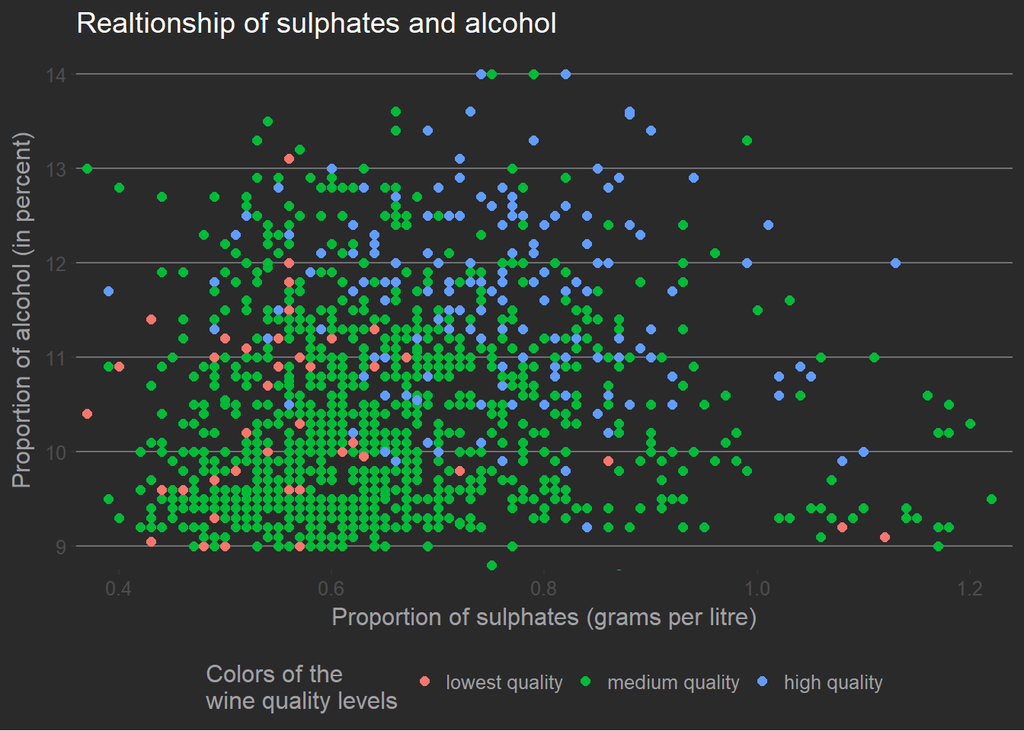

### Description Three

The third plot shows that the wines of high quality have on average higher alcohol values and at the same time higher proportions of sulphates. ——

# Reflection

It is difficult to find clear patterns in the chemical composition when evaluating wines. For example, there are individual variables that correlate with quality, such as alcohol content or volatile acidity. The sulphates and citric acid content also show a weaker correlation with quality. However, these variables do not correlate with each other. In other words: a wine with a lot of alcohol (which indicates a high quality) does not necessarily have a particularly low content of volatile acidity, at least not to the extent that the alcohol correlates with the quality.

This means that it may be difficult to put together the perfect “chemical recipe” for a good wine, even if there are some basic rules such as a low content of volatile acidity. Many different factors seem to have flowed into the assessments of the testers. To a certain extent, taste is simply a question of taste - and not of chemistry.